# Investigating Road Traffic Data for Wiltshire

## Contents

- Introduction
- Acquiring the data
- Data for Wiltshire
- Accidents in Wiltshire by Month
- Accidents in Wiltshire by Quarter
- Conclusion

## Introduction

Following on from [Exercise 5.2](https://learn2.open.ac.uk/mod/oucontent/view.php?id=1349956§ion=3.1) of TM351 I decided to download the same road safety information for the period 2005 to 2012 and look at the results for Wiltshire, the county that I live in. I specifically wanted to look at accidents and whether there are more accidents at certain times of years that others. The reason for doing this is that we typically associate poorer weather conditions with the autumn and winter months. We might make the assumption that the poorer the weather conditions the higher the number of accidents between September and March than between April to August.

The Jupyter Notebook containing the details of Exercise 5.2 looking at data from Milton Keynes can be accessed [here](http://nbviewer.jupyter.org/gist/psychemedia/c1ac132946fa120cad91).

Back to the top

## Acquiring the data

```python
#Road safety data
#http://data.gov.uk/dataset/road-accidents-safety-data
#First I downloaded the data using Linux command and the remote URL
!wget http://data.dft.gov.uk.s3.amazonaws.com/road-accidents-safety-data/Stats19-Data2005-2012.zip
```

```
--2018-10-27 14:10:25--  http://data.dft.gov.uk.s3.amazonaws.com/road-accidents-safety-data/Stats19-Data2005-2012.zip
Resolving data.dft.gov.uk.s3.amazonaws.com (data.dft.gov.uk.s3.amazonaws.com)... 52.218.52.145
Connecting to data.dft.gov.uk.s3.amazonaws.com (data.dft.gov.uk.s3.amazonaws.com)|52.218.52.145|:80... connected.
HTTP request sent, awaiting response... 200 OK
Length: 76235891 (73M) [application/x-zip-compressed]
Saving to: ‘Stats19-Data2005-2012.zip.3’

Stats19-Data2005-20 100%[===================>]  72.70M  3.76MB/s    in 20s

2018-10-27 14:10:46 (3.55 MB/s) - ‘Stats19-Data2005-2012.zip.3’ saved [76235891/76235891]
```

Next I need to unzip the files and store them in a directory for easy access.

```python
#Create a directory for this investigation
!mkdir data/accidents
```

```python
#The Linux commandline command unzip will unzip the downloaded file.
#The -d flag sets the target directory into which the unzipped files should be placed.
!unzip -d data/accidents Stats19-Data2005-2012.zip
```

```
Archive:  Stats19-Data2005-2012.zip
  inflating: data/accidents/Accidents0512.csv
  inflating: data/accidents/Vehicles0512.csv
  inflating: data/accidents/Casualty0512.csv
  inflating: data/accidents/Road-Accident-Safety-Data-Guide-1979-2004.xls
```

Back to the top

## Data for Wiltshire

For the purposes of this investigation I will want to use pandas library to create a dataframe and manipulate it.

```python
import pandas as pd
```

```python
#The dataset is far too large to read straight into a dataframe as it will take a long time to compile.
#As I only want a subset of the Accidents file then the first step is to look at the first few rows of data
#and identify how I can extract just the data for Wiltshire
pd.read_csv('data/accidents/Accidents0512.csv',nrows=3)
```

|  | Accident_Index | Location_Easting_OSGR | Location_Northing_OSGR | Longitude | Latitude | Police_Force | Accident_Severity | Number_of_Vehicles | Number_of_Casualties | Date | Day_of_Week | Time | ... | 2nd_Road_Class | 2nd_Road_Number | Pedestrian_Crossing-Human_Control | Pedestrian_Crossing-Physical_Facilities | Light_Conditions | Weather_Conditions | Road_Surface_Conditions | Special_Conditions_at_Site | Carriageway_Hazards | Urban_or_Rural_Area | Did_Police_Officer_Attend_Scene_of_Accident | LSOA_of_Accident_Location |
| --- | --- | --- | --- | --- | --- | --- | --- | --- | --- | --- | --- | --- | --- | --- | --- | --- | --- | --- | --- | --- | --- | --- | --- | --- | --- |
| 0 | 200501BS00001 | 525680 | 178240 | -0.191170 | 51.489096 | 1 | 2 | 1 | 1 | 04/01/2005 | 3 | 17:42 | ... | -1 | 0 | 0 | 1 | 1 | 2 | 2 | 0 | 0 | 1 | 1 | E01002849 |
| 1 | 200501BS00002 | 524170 | 181650 | -0.211708 | 51.520075 | 1 | 3 | 1 | 1 | 05/01/2005 | 4 | 17:36 | ... | 5 | 0 | 0 | 5 | 4 | 1 | 1 | 0 | 0 | 1 | 1 | E01002909 |
| 2 | 200501BS00003 | 524520 | 182240 | -0.206458 | 51.525301 | 1 | 3 | 2 | 1 | 06/01/2005 | 5 | 00:15 | ... | -1 | 0 | 0 | 0 | 4 | 1 | 1 | 0 | 0 | 1 | 1 | E01002857 |

3 rows × 32 columns

Looking at these headings there are two fields that I could possibly use to drill down to data for Wiltshire:-

- Police_Force - some police forces cover a county area
- LSOA_of_Accident_Location - LOSA stands for Lower Super Output Area and is a low level administrative geography area

I will begin by looking at whether I can use the police force number as an easy way of pulling out the data for Wiltshire. The first thing I need to do is find out what the numbers in the field Police Force stand for. One way of finding out more about the dataset is by visiting the original source of the data - in this case http://data.gov.uk/dataset/road-accidents-safety-data. Luckily supporting files for the dataset have been made available and this includes the [lookup tables for the variables](http://data.dft.gov.uk/road-accidents-safety-data/Road-Accident-Safety-Data-Guide.xls). This shows that 54 is used for the Wiltshire Police Force and so I will use this to extract accidents for Wiltshire.

The accidents dataset is very large so rather than load it all into a dataframe it makes sense to extract just the data for police force 54. In Exercise 5.2 it was suggested to use [csvkit](https://csvkit.readthedocs.io/en/latest/).

```python
!pip3 install csvkit
```

```
You are using pip version 10.0.1, however version 18.1 is available.
```

```python
#Now to filter out all the Wiltshire police force rows into a new file
!csvgrep -c Police_Force -m 54 data/accidents/Accidents0512.csv > data/accidents/wiltsAccidents.csv

#And this is how many lines of data I'll be dealing with
!wc -l data/accidents/wiltsAccidents.csv
```

```
12724 data/accidents/wiltsAccidents.csv
```

```python
#Now to create a dataframe so I can then organise by dates
wiltsAccidents = pd.read_csv('data/accidents/wiltsAccidents.csv')
wiltsAccidents[:6]
```

|  | Accident_Index | Location_Easting_OSGR | Location_Northing_OSGR | Longitude | Latitude | Police_Force | Accident_Severity | Number_of_Vehicles | Number_of_Casualties | Date | Day_of_Week | Time | ... | 2nd_Road_Class | 2nd_Road_Number | Pedestrian_Crossing-Human_Control | Pedestrian_Crossing-Physical_Facilities | Light_Conditions | Weather_Conditions | Road_Surface_Conditions | Special_Conditions_at_Site | Carriageway_Hazards | Urban_or_Rural_Area | Did_Police_Officer_Attend_Scene_of_Accident | LSOA_of_Accident_Location |
| --- | --- | --- | --- | --- | --- | --- | --- | --- | --- | --- | --- | --- | --- | --- | --- | --- | --- | --- | --- | --- | --- | --- | --- | --- | --- |
| 0 | 200554AD00205 | 414430 | 129210 | -1.795478 | 51.061989 | 54 | 3 | 1 | 1 | 01/01/2005 | 7 | 03:06 | ... | -1 | 0 | 0 | 0 | 4 | 1 | 1 | 0 | 0 | 1 | 1 | E01032023 |
| 1 | 200554AD00505 | 415030 | 130540 | -1.786861 | 51.073933 | 54 | 3 | 1 | 1 | 06/01/2005 | 5 | 17:05 | ... | 6 | 0 | 0 | 0 | 4 | 1 | 2 | 0 | 0 | 1 | 1 | E01032014 |
| 2 | 200554AD00805 | 414190 | 128570 | -1.798927 | 51.056240 | 54 | 3 | 3 | 1 | 09/01/2005 | 1 | 09:48 | ... | -1 | -1 | 0 | 0 | 1 | 1 | 2 | 0 | 2 | 1 | 1 | E01032006 |
| 3 | 200554AD01405 | 411780 | 131050 | -1.833234 | 51.078595 | 54 | 3 | 2 | 2 | 10/01/2005 | 2 | 15:07 | ... | 6 | 0 | 0 | 0 | 1 | 2 | 2 | 0 | 0 | 1 | 1 | E01032001 |
| 4 | 200554AD01605 | 414230 | 130760 | -1.798271 | 51.075932 | 54 | 3 | 2 | 1 | 12/01/2005 | 4 | 18:10 | ... | -1 | 0 | 0 | 0 | 4 | 1 | 2 | 0 | 0 | 1 | 1 | E01032020 |
| 5 | 200554AD02105 | 414460 | 128430 | -1.795081 | 51.054974 | 54 | 3 | 1 | 1 | 08/01/2005 | 7 | 02:38 | ... | 6 | 0 | 0 | 0 | 4 | 5 | 2 | 0 | 0 | 1 | 2 | E01032005 |

6 rows × 32 columns

Back to the top

## Accidents in Wiltshire by month

Now that I have pulled together the Wiltshire data from the UK wide results for 2005-2012 I can look at how many accidents there were per month. In order to do this I need to create a new column in the dataset and fill this in with the relevant month information.

However the first thing I need to do is find out what format the date information in the dataframe is as this will affect how I create the month field and fill it.

```python
wiltsAccidents.dtypes
```

```
Accident_Index                                  object
Location_Easting_OSGR                            int64
Location_Northing_OSGR                           int64
Longitude                                      float64
Latitude                                       float64
Police_Force                                     int64
Accident_Severity                                int64
Number_of_Vehicles                               int64
Number_of_Casualties                             int64
Date                                            object
Day_of_Week                                      int64
Time                                            object
Local_Authority_(District)                       int64
Local_Authority_(Highway)                       object
1st_Road_Class                                   int64
1st_Road_Number                                  int64
Road_Type                                        int64
Speed_limit                                      int64
Junction_Detail                                  int64
Junction_Control                                 int64
2nd_Road_Class                                   int64
2nd_Road_Number                                  int64
Pedestrian_Crossing-Human_Control                int64
Pedestrian_Crossing-Physical_Facilities          int64
Light_Conditions                                 int64
Weather_Conditions                               int64
Road_Surface_Conditions                          int64
Special_Conditions_at_Site                       int64
Carriageway_Hazards                              int64
Urban_or_Rural_Area                              int64
Did_Police_Officer_Attend_Scene_of_Accident      int64
LSOA_of_Accident_Location                       object
dtype: object
```

Now I need to create a new column for months and extract the month information from the Date field to populate it.

```python
#I have used dayfirst to ensure there is no confusion about the date format being dd/mm/yyyy
wiltsAccidents['Month'] = ([i.month for i in pd.to_datetime(wiltsAccidents['Date'],
    dayfirst=True)])
wiltsAccidents[:5]
```

|  | Accident_Index | Location_Easting_OSGR | Location_Northing_OSGR | Longitude | Latitude | Police_Force | Accident_Severity | Number_of_Vehicles | Number_of_Casualties | Date | Day_of_Week | Time | ... | 2nd_Road_Number | Pedestrian_Crossing-Human_Control | Pedestrian_Crossing-Physical_Facilities | Light_Conditions | Weather_Conditions | Road_Surface_Conditions | Special_Conditions_at_Site | Carriageway_Hazards | Urban_or_Rural_Area | Did_Police_Officer_Attend_Scene_of_Accident | LSOA_of_Accident_Location | Month |
| --- | --- | --- | --- | --- | --- | --- | --- | --- | --- | --- | --- | --- | --- | --- | --- | --- | --- | --- | --- | --- | --- | --- | --- | --- | --- |
| 0 | 200554AD00205 | 414430 | 129210 | -1.795478 | 51.061989 | 54 | 3 | 1 | 1 | 01/01/2005 | 7 | 03:06 | ... | 0 | 0 | 0 | 4 | 1 | 1 | 0 | 0 | 1 | 1 | E01032023 | 1 |
| 1 | 200554AD00505 | 415030 | 130540 | -1.786861 | 51.073933 | 54 | 3 | 1 | 1 | 06/01/2005 | 5 | 17:05 | ... | 0 | 0 | 0 | 4 | 1 | 2 | 0 | 0 | 1 | 1 | E01032014 | 1 |
| 2 | 200554AD00805 | 414190 | 128570 | -1.798927 | 51.056240 | 54 | 3 | 3 | 1 | 09/01/2005 | 1 | 09:48 | ... | -1 | 0 | 0 | 1 | 1 | 2 | 0 | 2 | 1 | 1 | E01032006 | 1 |
| 3 | 200554AD01405 | 411780 | 131050 | -1.833234 | 51.078595 | 54 | 3 | 2 | 2 | 10/01/2005 | 2 | 15:07 | ... | 0 | 0 | 0 | 1 | 2 | 2 | 0 | 0 | 1 | 1 | E01032001 | 1 |
| 4 | 200554AD01605 | 414230 | 130760 | -1.798271 | 51.075932 | 54 | 3 | 2 | 1 | 12/01/2005 | 4 | 18:10 | ... | 0 | 0 | 0 | 4 | 1 | 2 | 0 | 0 | 1 | 1 | E01032020 | 1 |

5 rows × 33 columns

Checking the first few lines of the dataframe I can see that the Month field has been populated, although using the month number rather than the month name. Whilst I could ask it to put the month name in rather than the number it will then order the months alphabetically when I come to do the `count` function. I have found it easier to use the number and then change the index names after.

The next step is to group the accidents by month.

```python
accidentsMonth = wiltsAccidents.groupby(['Month']).count()
accidentsMonth
```

| Month | Accident_Index | Location_Easting_OSGR | Location_Northing_OSGR | Longitude | Latitude | Police_Force | Accident_Severity | Number_of_Vehicles | Number_of_Casualties | Date | Day_of_Week | Time | ... | 2nd_Road_Class | 2nd_Road_Number | Pedestrian_Crossing-Human_Control | Pedestrian_Crossing-Physical_Facilities | Light_Conditions | Weather_Conditions | Road_Surface_Conditions | Special_Conditions_at_Site | Carriageway_Hazards | Urban_or_Rural_Area | Did_Police_Officer_Attend_Scene_of_Accident | LSOA_of_Accident_Location |
| --- | --- | --- | --- | --- | --- | --- | --- | --- | --- | --- | --- | --- | --- | --- | --- | --- | --- | --- | --- | --- | --- | --- | --- | --- | --- |
| 1 | 1053 | 1053 | 1053 | 1053 | 1053 | 1053 | 1053 | 1053 | 1053 | 1053 | 1053 | 1053 | ... | 1053 | 1053 | 1053 | 1053 | 1053 | 1053 | 1053 | 1053 | 1053 | 1053 | 1053 | 1053 |
| 2 | 1018 | 1018 | 1018 | 1018 | 1018 | 1018 | 1018 | 1018 | 1018 | 1018 | 1018 | 1018 | ... | 1018 | 1018 | 1018 | 1018 | 1018 | 1018 | 1018 | 1018 | 1018 | 1018 | 1018 | 1017 |
| 3 | 1027 | 1027 | 1027 | 1027 | 1027 | 1027 | 1027 | 1027 | 1027 | 1027 | 1027 | 1027 | ... | 1027 | 1027 | 1027 | 1027 | 1027 | 1027 | 1027 | 1027 | 1027 | 1027 | 1027 | 1026 |
| 4 | 957 | 957 | 957 | 957 | 957 | 957 | 957 | 957 | 957 | 957 | 957 | 957 | ... | 957 | 957 | 957 | 957 | 957 | 957 | 957 | 957 | 957 | 957 | 957 | 956 |
| 5 | 1059 | 1059 | 1059 | 1059 | 1059 | 1059 | 1059 | 1059 | 1059 | 1059 | 1059 | 1059 | ... | 1059 | 1059 | 1059 | 1059 | 1059 | 1059 | 1059 | 1059 | 1059 | 1059 | 1059 | 1059 |
| 6 | 1085 | 1085 | 1085 | 1085 | 1085 | 1085 | 1085 | 1085 | 1085 | 1085 | 1085 | 1085 | ... | 1085 | 1085 | 1085 | 1085 | 1085 | 1085 | 1085 | 1085 | 1085 | 1085 | 1085 | 1082 |
| 7 | 1113 | 1113 | 1113 | 1113 | 1113 | 1113 | 1113 | 1113 | 1113 | 1113 | 1113 | 1113 | ... | 1113 | 1113 | 1113 | 1113 | 1113 | 1113 | 1113 | 1113 | 1113 | 1113 | 1113 | 1112 |
| 8 | 1038 | 1038 | 1038 | 1038 | 1038 | 1038 | 1038 | 1038 | 1038 | 1038 | 1038 | 1038 | ... | 1038 | 1038 | 1038 | 1038 | 1038 | 1038 | 1038 | 1038 | 1038 | 1038 | 1038 | 1038 |
| 9 | 1106 | 1106 | 1106 | 1106 | 1106 | 1106 | 1106 | 1106 | 1106 | 1106 | 1106 | 1106 | ... | 1106 | 1106 | 1106 | 1106 | 1106 | 1106 | 1106 | 1106 | 1106 | 1106 | 1106 | 1106 |
| 10 | 1143 | 1143 | 1143 | 1143 | 1143 | 1143 | 1143 | 1143 | 1143 | 1143 | 1143 | 1143 | ... | 1143 | 1143 | 1143 | 1143 | 1143 | 1143 | 1143 | 1143 | 1143 | 1143 | 1143 | 1143 |
| 11 | 1099 | 1099 | 1099 | 1099 | 1099 | 1099 | 1099 | 1099 | 1099 | 1099 | 1099 | 1099 | ... | 1099 | 1099 | 1099 | 1099 | 1099 | 1099 | 1099 | 1099 | 1099 | 1099 | 1099 | 1099 |
| 12 | 1025 | 1025 | 1025 | 1025 | 1025 | 1025 | 1025 | 1025 | 1025 | 1025 | 1025 | 1025 | ... | 1025 | 1025 | 1025 | 1025 | 1025 | 1025 | 1025 | 1025 | 1025 | 1025 | 1025 | 1025 |

12 rows × 32 columns

The `groupby` function has included most of the fields in the dataset which isn't necessary for what I have planned. Looking at the information provided in the[lookup tables for the variables](http://data.dft.gov.uk/road-accidents-safety-data/Road-Accident-Safety-Data-Guide.xls) I can see that Accident_Index is a unique number so I can use this field to do a count.

```python
wiltsAccidentsMonth = pd.crosstab(wiltsAccidents['Month'], wiltsAccidents['Accident_Index'].count())
wiltsAccidentsMonth
```

| col_0 Month | 12723 |
| --- | --- |
| 1 | 1053 |
| 2 | 1018 |
| 3 | 1027 |
| 4 | 957 |
| 5 | 1059 |
| 6 | 1085 |
| 7 | 1113 |
| 8 | 1038 |
| 9 | 1106 |
| 10 | 1143 |
| 11 | 1099 |
| 12 | 1025 |

However having the month listed as a number won't necessarily help to identify months very easily in a resulting graph. I want to convert these to month names. Once this is done I will import the `matplotlib.pyplot` library so that I can produce a graph and see if there is a distinct difference between the number of accidents in Wiltshire per month

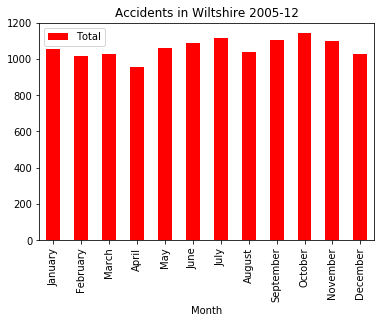

```python
allMonths ={1:'January', 2:'February', 3:'March', 4:'April', 5:'May', 6:'June', 7:'July', 8:'August', 9:'September',
            10:'October', 11:'November', 12:'December'}
#This next line then replaces the numbers with the correspinding month name using the allMonths dict above
wiltsAccidentsMonth.rename(index=allMonths, inplace=True)
#Rename the column containing the Totals
wiltsAccidentsMonth.columns = ['Total']
#Plot the resulting graph
import matplotlib.pyplot as plt
wiltsAccidentsMonth.plot.bar( xlim=(-1, 5), title='Accidents in Wiltshire 2005-12', color='red');
```

Although there is some variation between months this plot isn't helping me to answer whether there are more accidents in autumn and winter than spring and summer. What we can see is that April seem to have fewest accidents and October the most but surprisingly July seems to have a high number of accidents whilst December has a lower number of accidents than many of the months.

Back to the top

## Accidents in Wiltshire by Quarter

The next step is to look at the the information by quarter year as this may make it easier to see if there is a distinct pattern that conforms to the season. I will assign quarters as follows:-

- March Quarter = January, February, March (Winter)
- June Quarter = April, May, June (Spring)
- September Quarter = July, August, September (Summer)
- December Quarter = October, November, December (Autumn)

I will create a new column in the wiltsAccidents dataframe to add the quarter information and then generate a bar plot as before. If my assumption is correct then I expect the June and September Quarters to be smaller than the March and December quarters.

```python
#Define which months relate to which quarter
def label_quarter (row):
   if row['Month'] == 1 or row['Month'] == 2 or row['Month'] == 3 :
      return 'March'
   if row['Month'] == 4 or row['Month'] == 5 or row['Month'] == 6 :
      return 'June'
   if row['Month'] == 7 or row['Month'] == 8 or row['Month'] == 9 :
      return 'September'
   if row['Month'] == 10 or row['Month'] == 11 or row['Month'] == 12 :
      return 'December'
   else:
        return 'Unknown'

#Apply the labels I constructed above to the dataset
wiltsAccidents['Quarter'] =wiltsAccidents.apply (lambda row: label_quarter (row),axis=1)
#Quantify the results by quarter and relabel the total column
wiltsAccidentsQuarter = pd.crosstab(wiltsAccidents['Quarter'], wiltsAccidents['Accident_Index'].count())
wiltsAccidentsQuarter.columns = ['Total']
wiltsAccidentsQuarter
```

| Quarter | Total |
| --- | --- |
| December | 3267 |
| June | 3101 |
| March | 3098 |
| September | 3257 |

Now that I have quarterly figures I will plot these as a bar chart.

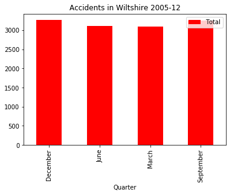

```python
wiltsAccidentsQuarter.plot.bar( xlim=(-1, 5), title='Accidents in Wiltshire 2005-12', color='red');
```

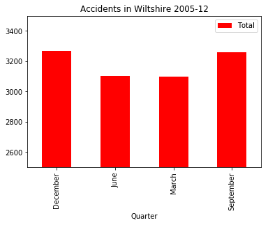

```python
wiltsAccidentsQuarter.plot.bar( xlim=(-1, 5), ylim=(2500,3500), title='Accidents in Wiltshire 2005-12', color='red');
```

This bar chart shows more clearly that December Quarter and September Quarter have a higher number of accidents than June and March. As the September Quarter covers July, August and September this is not what I expected!

I'm going to have a quick look at the stats using `describe` function to see if it provides any further information I can use.

```python
wiltsAccidentsQuarter.describe()
```

|  | Total |
| --- | --- |
| count | 4.000000 |
| mean | 3180.750000 |
| std | 93.916186 |
| min | 3098.000000 |
| 25% | 3100.250000 |
| 50% | 3179.000000 |
| 75% | 3259.500000 |
| max | 3267.000000 |

Looking at the maximum and minimum figures (which are 3098 and 3267) then the smallest and largest quarter only differ by less than 200 accidents. This means that given how large the numbers are they are fairly close to one another. On that basis it could be argued that the difference is not significant enough to draw attention to any differences between the quarters.

Back to the top

## Conclusion

The data analysis undertaken above on the statistics of road accidents for the period 2005 to 2012 don't support the supposition that there are likely to be more accidents in autumn and winter than there are in spring and summer in Wiltshire.

Going forward there are several other avenues of data analysis that could be undertaken. For example:-

- Expand the analysis to data for the whole of the country, not just Wiltshire - are the results by month and by quarter similar to the results for just Wiltshire?
- Compare the data against information about weather conditions to see if it is specifically weather rather than time of year that affects the results.
- Look at number of vehicles involved and look at whether number of vehicles involved (and therefore the possible severity of the accident) is higher in autumn and winter compared to spring and summer.

Back to the top